# REDStat Code Snippets

## WEEK 4 ANALYSIS OF VARIANCE (ANOVA)

### WK04 CODEALONG

- levels() >> showed heere the levels of catergorical variable
- how many observations of the column table(dataset1$Work)

```r
# Installing packages - uncomment the lines below if you need to install. ----
# install.packages("NHANES")
# install.packages("tidyverse")
# install.packages("emmeans")
# install.packages("car")

# Loading libraries
library(NHANES) # for the dataset
library(tidyverse) # for wrangling and plotting
library(emmeans) # for post-hoc tests
library(car) # for Levene's test
# NULL HYPOTHESIS: Working status doesn't affect the number of hours of sleep per night ----

summary(NHANES) # to see descriptive statistics of all variables
```

```
##        ID           SurveyYr       Gender          Age          AgeDecade
##  Min.   :51624   2009_10:5000   female:5020   Min.   : 0.00    40-49 :1398
##  1st Qu.:56905   2011_12:5000   male  :4980   1st Qu.:17.00    0-9   :1391
##  Median :62160                                Median :36.00    10-19 :1374
##  Mean   :61945                                Mean   :36.74    20-29 :1356
##  3rd Qu.:67039                                3rd Qu.:54.00    30-39 :1338
##  Max.   :71915                                Max.   :80.00   (Other):2810
##                                                               NA's   : 333
##    AgeMonths          Race1           Race3               Education
##  Min.   :  0.0   Black   :1197   Asian   : 288   8th Grade     : 451
##  1st Qu.:199.0   Hispanic: 610   Black   : 589   9 - 11th Grade: 888
##  Median :418.0   Mexican :1015   Hispanic: 350   High School   :1517
##  Mean   :420.1   White   :6372   Mexican : 480   Some College  :2267
##  3rd Qu.:624.0   Other   : 806   White   :3135   College Grad  :2098
##  Max.   :959.0                   Other   : 158   NA's          :2779
##  NA's   :5038                    NA's    :5000
##       MaritalStatus         HHIncome     HHIncomeMid        Poverty
##  Divorced    : 707   more 99999 :2220   Min.   :  2500   Min.   :0.000
##  LivePartner : 560   75000-99999:1084   1st Qu.: 30000   1st Qu.:1.240
##  Married     :3945   25000-34999: 958   Median : 50000   Median :2.700
##  NeverMarried:1380   35000-44999: 863   Mean   : 57206   Mean   :2.802
##  Separated   : 183   45000-54999: 784   3rd Qu.: 87500   3rd Qu.:4.710
##  Widowed     : 456   (Other)    :3280   Max.   :100000   Max.   :5.000
##  NA's        :2769   NA's       : 811   NA's   :811      NA's   :726
##    HomeRooms       HomeOwn             Work          Weight
##  Min.   : 1.000   Own  :6425   Looking   : 311   Min.   :  2.80
##  1st Qu.: 5.000   Rent :3287   NotWorking:2847   1st Qu.: 56.10
##  Median : 6.000   Other: 225   Working   :4613   Median : 72.70
##  Mean   : 6.249   NA's :  63   NA's      :2229   Mean   : 70.98
##  3rd Qu.: 8.000                                  3rd Qu.: 88.90
##  Max.   :13.000                                  Max.   :230.70
##  NA's   :69                                      NA's   :78
##      Length          HeadCirc         Height           BMI
##  Min.   : 47.10   Min.   :34.20   Min.   : 83.6   Min.   :12.88
##  1st Qu.: 75.70   1st Qu.:39.58   1st Qu.:156.8   1st Qu.:21.58
##  Median : 87.00   Median :41.45   Median :166.0   Median :25.98
##  Mean   : 85.02   Mean   :41.18   Mean   :161.9   Mean   :26.66
##  3rd Qu.: 96.10   3rd Qu.:42.92   3rd Qu.:174.5   3rd Qu.:30.89
##  Max.   :112.20   Max.   :45.40   Max.   :200.4   Max.   :81.25
##  NA's   :9457     NA's   :9912    NA's   :353     NA's   :366
```

[output cut: 89 more lines]

```
##  No  : 223   Min.   : 9.00   Min.   :   0.00   Min.   : 0.000   No  :5353
##  Yes :5544   1st Qu.:15.00   1st Qu.:   2.00   1st Qu.: 1.000   Yes : 415
##  NA's:4233   Median :17.00   Median :   5.00   Median : 1.000   NA's:4232
##              Mean   :17.43   Mean   :  15.09   Mean   : 1.342
##              3rd Qu.:19.00   3rd Qu.:  12.00   3rd Qu.: 1.000
##              Max.   :50.00   Max.   :2000.00   Max.   :69.000
##              NA's   :4460    NA's   :4275      NA's   :5072
##       SexOrientation  PregnantNow
##  Bisexual    : 119   Yes    :  72
##  Heterosexual:4638   No     :1573
##  Homosexual  :  85   Unknown:  51
##  NA's        :5158   NA's   :8304
##
##
##
```

```r
# We will keep only adults (aged 18 and over)
# and three variables: HealthGen, SleepHrsNight, and Work
dataset1 <- NHANES %>%
  filter(Age > 18) %>%
  select(HealthGen, SleepHrsNight, Work)

summary(dataset1)
```

```
##      HealthGen    SleepHrsNight            Work
##  Excellent: 764   Min.   : 2.000   Looking   : 277
##  Vgood    :2130   1st Qu.: 6.000   NotWorking:2579
##  Good     :2603   Median : 7.000   Working   :4515
##  Fair     : 931   Mean   : 6.894   NA's      :   1
##  Poor     : 180   3rd Qu.: 8.000
##  NA's     : 764   Max.   :12.000
##                   NA's   :17
```

```r
# we see that there are three categories for the Work variable
# this shows that Work has 1 missing value (NA) and SleepHrsNight has 17
head(dataset1)
```

```
## # A tibble: 6 × 3
##   HealthGen SleepHrsNight Work
##   <fct>             <int> <fct>
## 1 Good                  4 NotWorking
## 2 Good                  4 NotWorking
## 3 Good                  4 NotWorking
## 4 Good                  8 NotWorking
## 5 Vgood                 8 Working
## 6 Vgood                 8 Working
```

```r
# We see that the Work variable is a factor
# How many levels (or categories) does Work have?
# Using base R
levels(dataset1$Work)
```

```
## [1] "Looking"    "NotWorking" "Working"
```

```r
# How many observations in each Work group?
# Using base R
table(dataset1$Work)
```

```
##
##    Looking NotWorking    Working
##        277       2579       4515
```

```r
# Using the Tidyverse
dataset1 %>%
  pull(Work) %>% # extract Work as a vector (of factor type)
  fct_count()
```

```
## # A tibble: 4 × 2
##   f              n
##   <fct>      <int>
## 1 Looking      277
## 2 NotWorking  2579
## 3 Working     4515
## 4 <NA>           1
```

```r
# As seen in the summary() output, Work has three categories:
# Looking, NotWorking and Working

# Check the general structure of our dataset1
str(dataset1)
```

```
## tibble [7,372 × 3] (S3: tbl_df/tbl/data.frame)
##  $ HealthGen    : Factor w/ 5 levels "Excellent","Vgood",..: 3 3 3 3 2 2 2 2 2 4 ...
##  $ SleepHrsNight: int [1:7372] 4 4 4 8 8 8 8 7 5 4 ...
##  $ Work         : Factor w/ 3 levels "Looking","NotWorking",..: 2 2 2 2 3 3 3 2 3 3 ...
```

```r
# Calculate the mean number of hours slept at night for each Work category
# The group_by() function will run subsequent functions separately for each
# category of the Work variable.
dataset1 %>%
  group_by(Work) %>%
  summarise(mean=mean(SleepHrsNight))
```

```
## # A tibble: 4 × 2
##   Work        mean
##   <fct>      <dbl>
## 1 Looking       NA
## 2 NotWorking    NA
## 3 Working       NA
## 4 <NA>           6
```

```r
# The NA results are caused by missing values for SleepHrsNight in all three
# Work categories

# So we will update dataset1 by removing the rows with missing Work or SleepHrsNight data
# Note that there are many other ways to deal with missing data, not covered here
# If we don't remove missing data at the start, we will need to add the na.rm=T
# argument to functions like mean(), sd(), var(), etc.

# Add the na.rm = TRUE argument in the mean function to remove only missing data
# within that function call.
dataset1 %>%
  group_by(Work) %>%
  summarise(mean = mean(SleepHrsNight, na.rm = TRUE))
```

```
## # A tibble: 4 × 2
##   Work        mean
##   <fct>      <dbl>
## 1 Looking     7.00
## 2 NotWorking  7.04
## 3 Working     6.80
## 4 <NA>        6
```

```r
# Update dataset1 to remove all rows with missing data for either SleepHrsNight or Work
dataset1 <- dataset1 %>%
  drop_na(SleepHrsNight,Work)

# Now we can calculate the mean, standard deviation and variance for SleepHrsNight
# for each Work category
sleep_descriptives_by_workingstatus <- dataset1 %>%
  group_by(Work) %>%
  summarise(mean=mean(SleepHrsNight),
            sd = sd(SleepHrsNight),
            var = var(SleepHrsNight))
# View the summary statistics tibble we just created
sleep_descriptives_by_workingstatus
```

```
## # A tibble: 3 × 4
##   Work        mean    sd   var
##   <fct>      <dbl> <dbl> <dbl>
## 1 Looking     7.00  1.42  2.00
## 2 NotWorking  7.04  1.53  2.34
## 3 Working     6.80  1.20  1.43
```

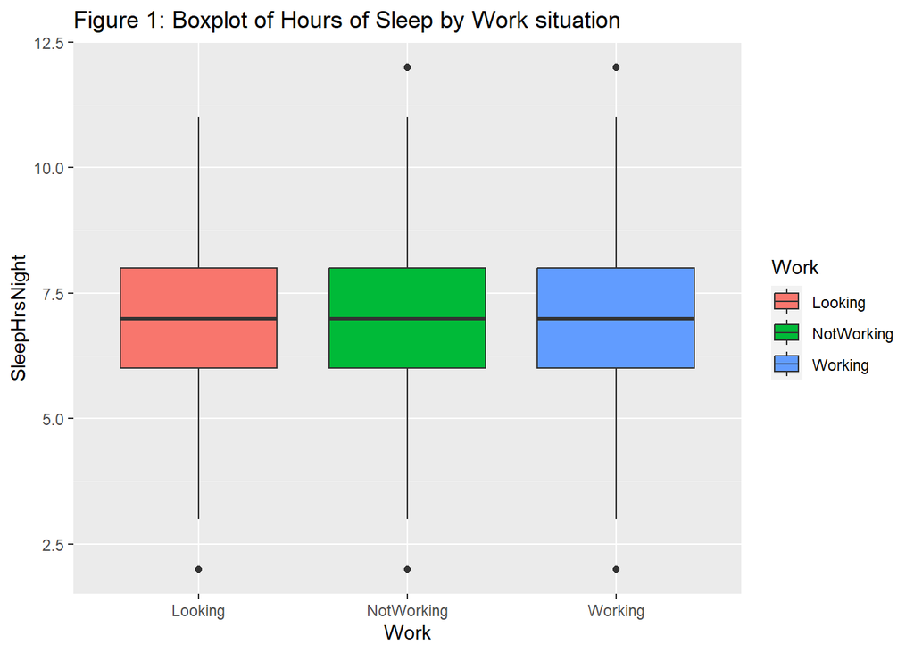

```r
# This table suggests that Working individuals have slightly less sleep than others,
# especially when compared with NotWorking individuals.

# Boxplot to visualise differences before ANOVA  ----
dataset1 %>%
# colour each boxplot by working status with the fill argument
  ggplot(aes(x = Work, y = SleepHrsNight, fill = Work)) +
  geom_boxplot() +
  # add a title for the plot
  labs(title = "Figure 1: Boxplot of Hours of Sleep by Work situation")
```

```r
# The boxplots seem very similar, symmetrical around the centre, and
# with similar centre and variability across categories,
# but large sample sizes might bring small differences out.

# Perform the ANOVA  ----
ANOVA1 <- aov(SleepHrsNight~Work, data=dataset1)
# This doesn’t give any output, for that you need to use the summary() function.
# The summary() function will create a table with one row for each categorical
# variable and each interaction term, if you have any.
summary(ANOVA1)
```

```
##               Df Sum Sq Mean Sq F value   Pr(>F)
## Work           2     98   48.99   27.65 1.08e-12 ***
## Residuals   7351  13023    1.77
## ---
## Signif. codes:  0 '***' 0.001 '**' 0.01 '*' 0.05 '.' 0.1 ' ' 1
```

```r
# There is one row for the Work variable, which shows the among group information,
# and one row for the residuals.
# For each row, there is the number of degrees of freedom, the sum of squares,
# and the mean square
# For the Work variable (treatment, or explanatory variable), there is also
# the F-value and the associated p-value.
# Here the df for Work is 3 (Work categories) - 1 = 2
# df for the residuals = 7354 observations - Work categories = 7351
# Work Sum of squares = differences among Work categories
# Residual Sum of squares = variation within Work categories
# Mean Square = SS / df
# F = MS among / MS within = 48.99 / 1.77
# Small p-value: strong evidence that Work category influences the number of
# hours of sleep at night

# POST-HOC TESTS  ----
# Evidence for differences among Work categories
# Compare means among Work categories
anova1_emmeans <- emmeans(ANOVA1,"Work")
anova1_emmeans
```

```
##  Work       emmean     SE   df lower.CL upper.CL
##  Looking      7.00 0.0801 7351     6.85     7.16
##  NotWorking   7.04 0.0263 7351     6.99     7.10
##  Working      6.80 0.0198 7351     6.76     6.84
##
## Confidence level used: 0.95
```

```r
# This outputs a table with a row for each Work category
# It gives a mean, standard error, number of df,
# lower and upper boundaries of the confidence intervals for
# these means. The standard error uses the standard deviation
# of the residuals estimated from the model
# SE = SD / sqrt(n)
SD_residuals<-sigma(ANOVA1)
n_looking<-dataset1 %>%
  group_by(Work) %>%
  count(Work) %>%
  filter(Work=="Looking") %>%
  ungroup() %>%
  select(n)
SE_looking<-SD_residuals/sqrt(n_looking) # 0.0801

# Pairwise comparisons  ----
anova1_pairs <- pairs(anova1_emmeans)
anova1_pairs
```

```
##  contrast             estimate     SE   df t.ratio p.value
##  Looking - NotWorking    -0.04 0.0843 7351  -0.475  0.8832
##  Looking - Working        0.20 0.0825 7351   2.429  0.0402
##  NotWorking - Working     0.24 0.0329 7351   7.306  <.0001
##
## P value adjustment: tukey method for comparing a family of 3 estimates
```

```r
# estimate = effect size, difference between means for pairs of Work categories
# e.g. Looking - NotWorking = 7-7.04 = -0.04
# SE = standard error for this difference / effect size
# t.ratio and p.value are t-statistic and p-value for Tukey's
# test with H0: the difference between the means = 0
# Highly significant for NotWorking vs Working
# **Tukey's** "Honest Significant Differences" test
# corrects for multiple pairwise tests,
# therefore no increase of type 1 error

# Similar output, with 95% CI, also corrected for multiple
# testing, instead of t-statistic and p-value
confint(anova1_pairs)
```

```
##  contrast             estimate     SE   df lower.CL upper.CL
##  Looking - NotWorking    -0.04 0.0843 7351 -0.23768    0.158
##  Looking - Working        0.20 0.0825 7351  0.00696    0.394
##  NotWorking - Working     0.24 0.0329 7351  0.16331    0.318
##
## Confidence level used: 0.95
## Conf-level adjustment: tukey method for comparing a family of 3 estimates
```

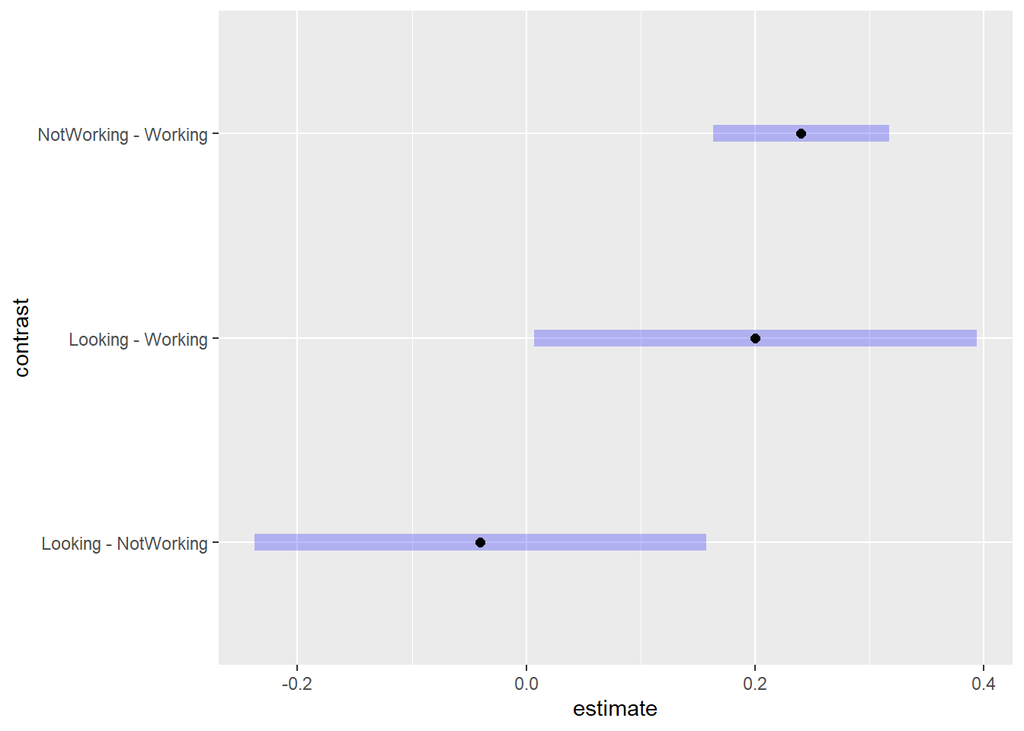

```r
# Largest difference (NotWorking vs Working) has a positive
# adjusted 95% CI, doesn't overlap 0

# Plot confidence intervals
plot(confint(anova1_pairs))
```

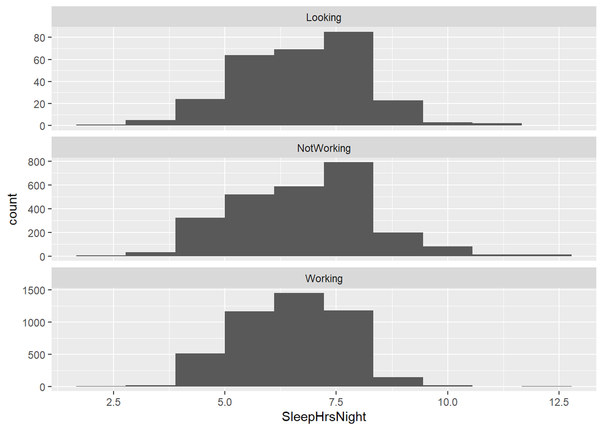

```r
# ASSUMPTIONS  of the ANOVA
# 1) Independent data
# 2) Normality
# 3) Homogeneity of variance

# 1) Independent data

# As we've seen before, each row of the NHANES dataset should be a
# different individual, therefore the assumption of independence is met.

# 2) Normality

# Histogram
dataset1 %>%
  ggplot(aes(x = SleepHrsNight)) +
  geom_histogram(bins = 10) +
  facet_wrap(facets = ~Work, ncol = 1, scales = "free_y")
```

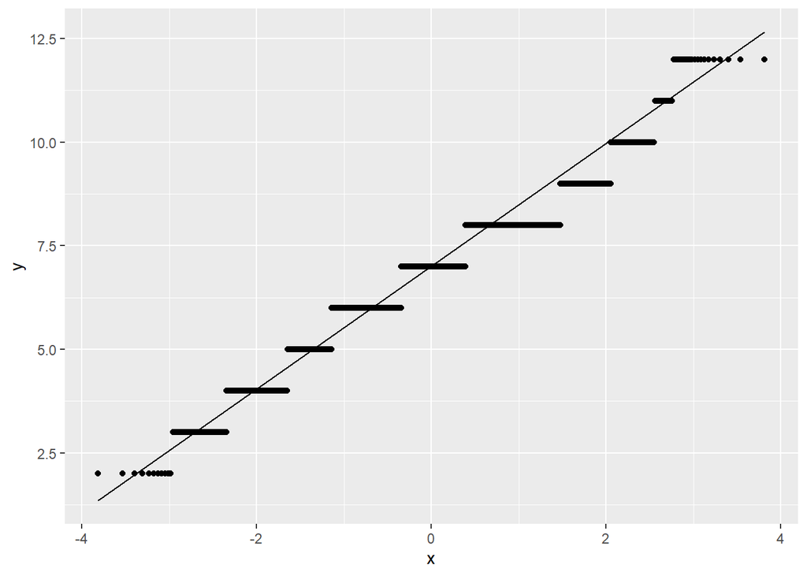

```r
# Q-Q plot to assess normal distribution of SleepHrsNight
ggplot(dataset1, aes(sample = SleepHrsNight)) +
  stat_qq() + # this line plots the error terms
  stat_qq_line() # this line plots the regression line
```

```r
# The histograms and Q-Q plot suggest that SleepHrsNight comes from a normal
# distribution.

# Shapiro-Wilk normality test   ----
# shapiro.test(dataset1$SleepHrsNight)
# The error message says we can't have more than 5000 observations.

# We create a random sample of dataset1 with just 4000 observations.
sample <- slice_sample(dataset1, n = 4000)
shapiro.test(sample$SleepHrsNight)
```

```
##
##  Shapiro-Wilk normality test
##
## data:  sample$SleepHrsNight
## W = 0.93712, p-value < 2.2e-16
```

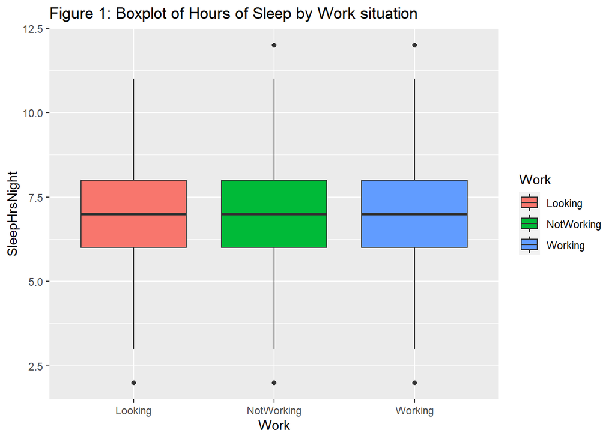

```r
# Significant departure from normality, maybe due to large sample.

# 3) Homogeneity of variance ----

# Boxplot as before
dataset1 %>%
  ggplot(aes(x = Work, y = SleepHrsNight, fill = Work)) +
  geom_boxplot() +
  labs(title = "Figure 1: Boxplot of Hours of Sleep by Work situation")
```

```r
# The boxplots suggest that there is equal variance  of
# SleepHrsNight between Work categories
# Can also use Bartlett's test of homogeneity of variances
# H0: variances are equal across groups
bartlett.test(dataset1$SleepHrsNight~dataset1$Work)
```

```
##
##  Bartlett test of homogeneity of variances
##
## data:  dataset1$SleepHrsNight by dataset1$Work
## Bartlett's K-squared = 204.83, df = 2, p-value < 2.2e-16
```

```r
# Or Levene's test if the variable is not normally distributed
# Levene's test with one independent variable
leveneTest(SleepHrsNight ~ Work, data = dataset1)
```

```
## Levene's Test for Homogeneity of Variance (center = median)
##         Df F value    Pr(>F)
## group    2  80.711 < 2.2e-16 ***
##       7351
## ---
## Signif. codes:  0 '***' 0.001 '**' 0.01 '*' 0.05 '.' 0.1 ' ' 1
```

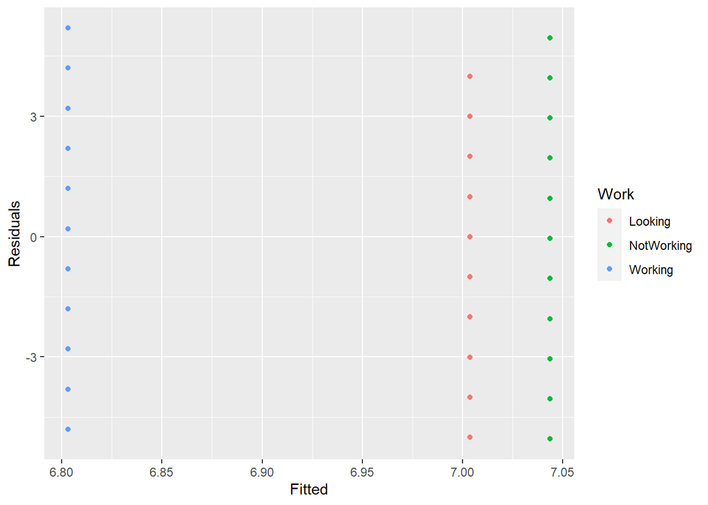

```r
## BONUS PLOT ----
## Residual plot to see if the residuals are similarly distributed across groups.

# Create a tibble with the fitted values, residuals and Work category
Model <- tibble(Fitted = fitted(ANOVA1), # extracts fitted values from ANOVA1
                Residuals = resid(ANOVA1), # extracts residuals from ANOVA1
                Work = dataset1$Work) # takes the Work categories from dataset1

# Create a residual plot for the ANOVA model, which shows the residuals for
# each Work category The residuals on the y-axis are the differences between
# the actual data points and the fitted values. The fitted values on the x-axis
# are the means for each treatment. We expect residuals to have a mean of 0 if
# there is a symmetric distribution of SleepHrsNight for each Work category.
# The residuals shouldn't show any pattern and be roughly evenly distributed
# above and below 0.
ggplot(Model, aes(Fitted, Residuals, colour = Work)) +
  geom_point()
```

### WK04 LAB

```r
# Week 4 lab - ANOVA with the NHANES dataset

### Introduction ###

# In this self-guided lab, you will be running an ANOVA. We will be using
# a significance level of 5% throughout.

# We'll be using functions from the tidyverse collection of packages, as
# well as from the emmeans package, and we will use the NHANES dataset
# again, so let's load them in.

library(tidyverse)
library(emmeans)
library(NHANES)

# The messages above are telling us which functions from the base R are
# overwritten by functions from the Tidyverse, and that some packages were
# set up using a previous version of R.

### ANOVA exercise ###

# Let's explore whether people who watch more TV also tend to have a
# higher body mass index (BMI), indicating that they are more likely to be
# overweight or obese. We will use a one-way ANOVA to answer this
# question.

# In order to meet the assumptions for ANOVA, we will restrict the NHANES
# dataset a little bit. This is just for demonstration purposes, if you
# were given a real dataset, you would need to analyse the whole dataset,
# rather than restricting it.

# Let's create a new dataset, called NHANES_ANOVA, where we will create a
# new version of the variable about watching TV - my TV_categorical
# variable will only have 3 levels, and it will indicate whether someone
# watches TV less than the median (i.e.less than 2 hours a day), at the
# median (2 hours a day), or more than the median (3 or more hours). We
# will also filter out people with BMI over 40 (again, this is for
# demonstration purposes only).

NHANES_ANOVA <- NHANES %>%
  # creating a TV_categorical variable with 3 levels
  mutate(TV_categorical = case_when(TVHrsDay == "0_hrs"|TVHrsDay == "0_to_1_hr"|
                                      TVHrsDay == "1_hr" ~ "less_than_median",
                                    TVHrsDay == "2_hr" ~ "median",
                                    TVHrsDay == "3_hr"|TVHrsDay == "4_hr"|
                                      TVHrsDay == "More_4_hr"
                                    ~ "more_than_median")) %>%
  # removing people with a missing value for TV_categorical
  drop_na(TV_categorical) %>%
  # filtering out people with BMI of 40 or more
  filter(BMI < 40)

# Now we will have a quick look at our NHANES_ANOVA subset to see how many
# people there are in each category.

table(NHANES_ANOVA$TV_categorical)
```

```
##
## less_than_median           median more_than_median
##             1590             1211             1792
```

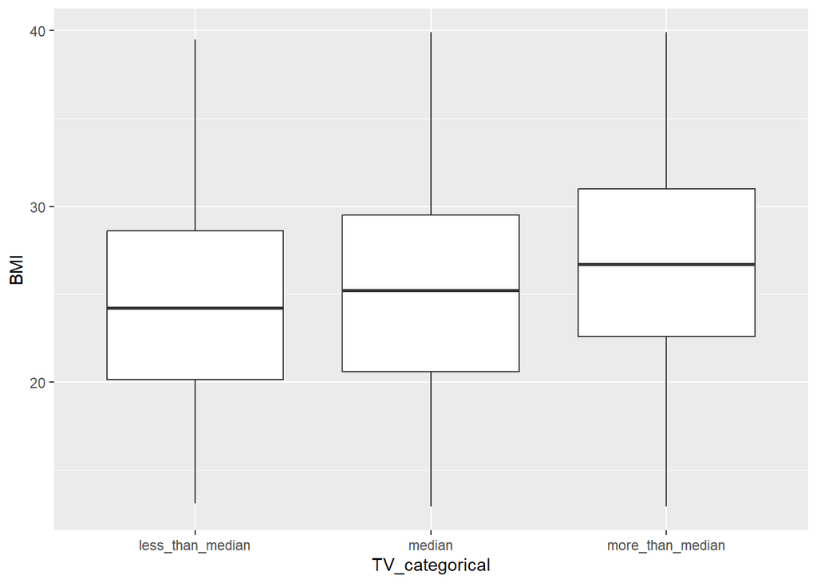

```r
## Task 1: Dataset exploration.

# Let's create a box plot and a table of summary statistics including mean
# and standard deviation to see what the pattern is for BMI across
# TV_categorical groups. Based on the descriptive statistics and the
# boxplot, what pattern do you see in the data?

## Your solution
NHANES_ANOVA %>%
  ggplot(aes(x = TV_categorical, y = BMI)) +
  geom_boxplot()
```

```r
NHANES_ANOVA %>%
  group_by(TV_categorical) %>%
  summarise(mean_BMI = mean(BMI, na.rm = TRUE),
  sd_BMI = sd(BMI, na.rm = TRUE))
```

```
## # A tibble: 3 × 3
##   TV_categorical   mean_BMI sd_BMI
##   <chr>               <dbl>  <dbl>
## 1 less_than_median     24.4   5.97
## 2 median               25.2   5.99
## 3 more_than_median     26.8   5.86
```

```r
# The BMI variable has a higher median in the group with the individuals who
# watch TV for more hours than the median than in both other groups, with a
# larger difference between the group with the least hours of TV watched and the
# group with the most hours of TV watched. The variance seems similar between
# the groups.

## Task 2: ANOVA

# Let's run an ANOVA to test if what we're seeing is statistically
# significant. How would you interpret the results of the ANOVA?

## Your solution

ANOVA1 <- aov(BMI~TV_categorical, data = NHANES_ANOVA)
summary(ANOVA1)
```

```
##                  Df Sum Sq Mean Sq F value Pr(>F)
## TV_categorical    2   4838  2418.9   68.76 <2e-16 ***
## Residuals      4590 161467    35.2
## ---
## Signif. codes:  0 '***' 0.001 '**' 0.01 '*' 0.05 '.' 0.1 ' ' 1
```

```r
# The p-value for the F-statistic of the ANOVA is highly significant
# (p<2.2x10-16), suggesting that there is an overall effect of the number of
# hours of TV watched on the BMI of individuals.

## Task 3: Post-hoc tests

# As you know, ANOVA is an omnibus test, so it doesn't tell us where the
# significant differences lie. We need to look at post-hoc comparisons to
# tell us which groups are different. Let's do it using Tukey's HSD test
# for each pairwise comparison. We would like to get the differences in
# means, their test statistic and associated p-value, standard error and
# confidence interval. How would you interpret the results of this test?

## Your solution
anova1_emmeans <- emmeans(ANOVA1,"TV_categorical")
anova1_emmeans
```

```
##  TV_categorical   emmean    SE   df lower.CL upper.CL
##  less_than_median   24.4 0.149 4590     24.1     24.7
##  median             25.2 0.170 4590     24.9     25.5
##  more_than_median   26.8 0.140 4590     26.5     27.0
##
## Confidence level used: 0.95
```

```r
anova1_pairs <- pairs(anova1_emmeans)
anova1_pairs
```

```
##  contrast                            estimate    SE   df t.ratio p.value
##  less_than_median - median             -0.781 0.226 4590  -3.454  0.0016
##  less_than_median - more_than_median   -2.348 0.204 4590 -11.493  <.0001
##  median - more_than_median             -1.567 0.221 4590  -7.103  <.0001
##
## P value adjustment: tukey method for comparing a family of 3 estimates
```

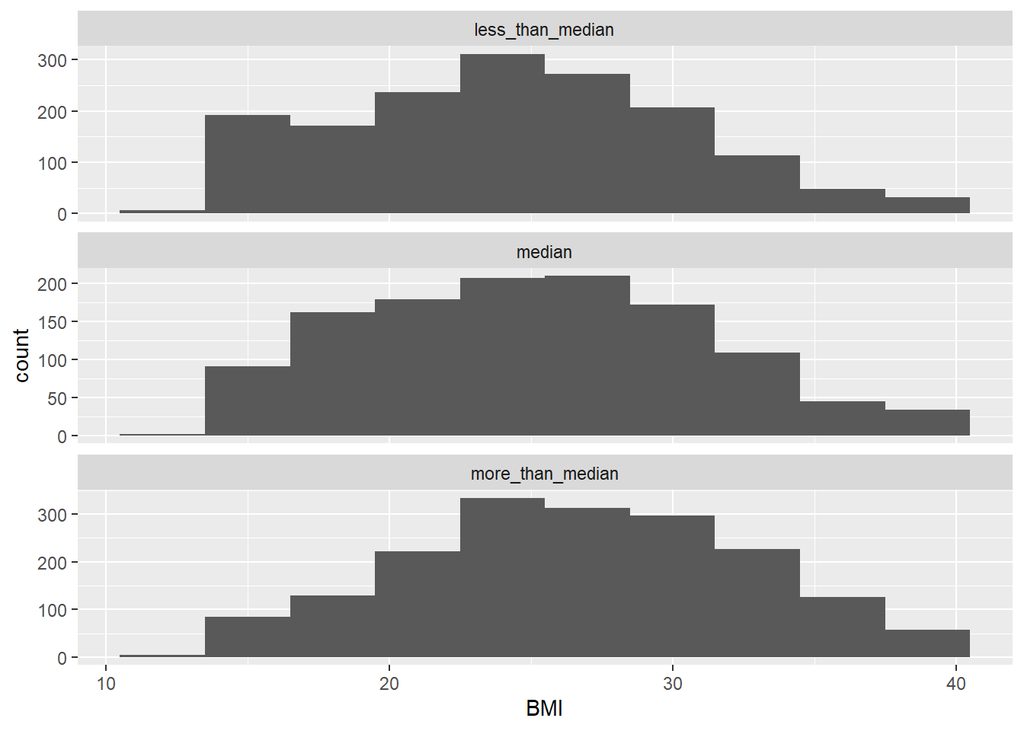

```r
# All three pairwise comparisons are significant at the 5% significance level,
# with all p-values smaller than 0.002 and 95% confidence intervals not
# overlapping 0. The largest difference in means is -2.348 for the comparison
# between the more_than_median and the less_than_median groups.


## Task 4: Checking the assumptions.

# Let's check the assumptions.

#-   4.1. Independence. Would you say that the data meet the independence
#    assumption? Are the groupings independent of one another? Is each
#    observation independent of the others?

#-   4.2. Homogeneity of variance. Does the BMI variable have a similar
#    variance among the three groups? Run a Bartlett's test to check. How
#    would you interpret the results of this test?

#-   4.3. Normality. Does the BMI variable come from a normal
#    distribution? Use both visual inspection of the distribution and
#    hypothesis test. How would you interpret the plot and the test
#    results?

## Your solution

# Create a histogram of BMI at each level of TV_categorical.
NHANES_ANOVA %>%
  ggplot(aes(x = BMI)) + geom_histogram(bins = 10) +
  facet_wrap(facets = ~TV_categorical, ncol = 1, scales = "free_y")
```

```r
# Let's run the Shapiro-Wilk normality test.
shapiro.test(NHANES_ANOVA$BMI)
```

```
##
##  Shapiro-Wilk normality test
##
## data:  NHANES_ANOVA$BMI
## W = 0.98757, p-value < 2.2e-16
```

```r
# The Shapiro-Wilk test has a very low p-value (p<2.2e-16), suggesting that the
# BMI variable doesn’t come from a normal distribution. The large sample size
# may be picking a small deviation from the normal distribution, so this result
# alone doesn’t mean that the assumption of normality is not met.
```

## WEEK 5

### wk05_t01

Correlation coefficients

summarise(correlation = cor(Weight, Height, use = “complete.obs”)): The summarise function collapses the dataset into a single summary value per group (or the entire dataset if not grouped). Here, it’s used to calculate a single summary statistic:

correlation =: This part assigns the result of the correlation computation to a new summary variable called correlation.

cor(Weight, Height, use = “complete.obs”): The cor function calculates Pearson’s correlation coefficient between two variables. In this case, it calculates the correlation between Weight and Height.

**The use = “complete.obs”** argument specifies that the calculation should use only complete pairs of observations. This means that any rows with missing (NA) values for either Weight or Height are excluded from the correlation computation.

pull(Weight): **The pull function is used to extract just the Weight column from the filtered dataset. This function returns a vector** containing the values of the Weight column for the filtered subset of the data (i.e., male individuals aged 18 and above).

**Output: The output of cor.test() includes several important pieces of information:**

The Pearson correlation coefficient (r), which quantifies the degree of linear association between the two variables. Its value ranges from -1 to 1, where -1 indicates a perfect negative linear relationship, 1 indicates a perfect positive linear relationship, and 0 indicates no linear relationship. The p-value, which indicates the probability of observing the data (or something more extreme) assuming the null hypothesis is true. A small p-value (typically ≤ 0.05) suggests that the observed correlation is unlikely to have occurred by chance, leading to the rejection of the null hypothesis. The confidence interval for the correlation coefficient, which provides a range of values within which the true correlation coefficient is likely to fall, with a certain level of confidence (usually 95%).

The result you’ve provided is from a Pearson’s product-moment correlation test conducted between two variables, presumably Weight and Height. Here’s a breakdown of what each part of the output means:

**Test Type:** “Pearson’s product-moment correlation” indicates the type of correlation test that was conducted. This test measures the linear relationship between two continuous variables.

**Data:** “data: Weight and Height” specifies the two variables involved in the correlation analysis.

**Test Statistic (t): “t = 25.711”** represents the value of the test statistic used in testing the hypothesis about the correlation. This value is calculated based on the sample correlation coefficient and the sample size, and it is used to determine the p-value.

**Degrees of Freedom (df): “df = 3649”** indicates the degrees of freedom for the test, which is related to the number of data points involved in the analysis. In correlation tests, the degrees of freedom are typically the number of data pairs minus 2.

**P-value: “p-value < 2.2e-16”** signifies the probability of observing a correlation as strong as the one in your data (or stronger) if **the null hypothesis of no correlation (correlation coefficient = 0) were true.** A p-value this small (less than the smallest number representable in standard statistical software, which is often 2.2e-16) **indicates extremely strong evidence against the null hypothesis, leading to its rejection.**

Alternative Hypothesis: “alternative hypothesis: true correlation is not equal to 0” states the hypothesis being tested against the null hypothesis. In this case, it suggests that the actual correlation between Weight and Height is different from zero.

95 Percent Confidence Interval: “0.3638145 0.4187508” provides the range within which the true population correlation coefficient is likely to fall, with 95% confidence. This interval does not include zero, which further supports the conclusion that there is a significant correlation between the variables.

In summary, the test results provide strong evidence of a significant positive linear relationship between Weight and Height, with a moderate correlation coefficient of approximately 0.392.

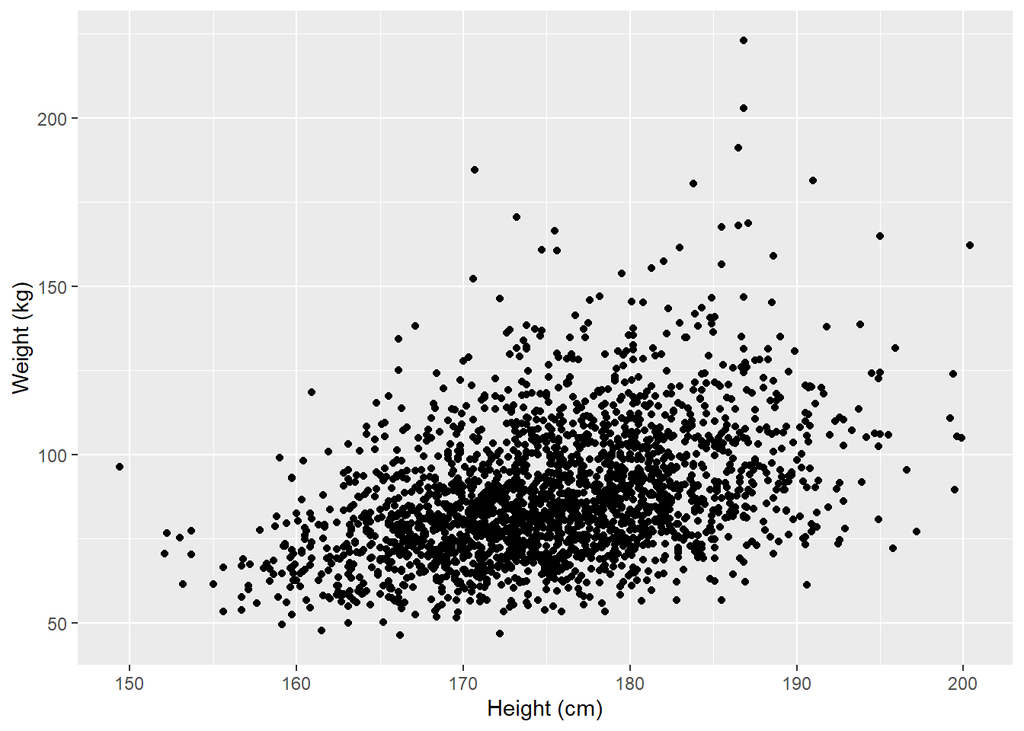

```r
# Take the NHANES dataset, then filter to keep only adult males, then create a scatter plot of Weight against Height
NHANES %>%
  filter(Gender == "male", Age >= 18) %>%
  ggplot(aes(x = Height, y = Weight)) +
  geom_point() +
  xlab("Height (cm)") +
  ylab("Weight (kg)")
```

```r
# Using the same dataset as for the scatterplot, we use the summarise function to calculate the Pearson's correlation coefficient
NHANES %>%
  filter(Gender == "male", Age >= 18) %>%
  summarise(correlation = cor(Weight, Height, use = "complete.obs"))
```

```
## # A tibble: 1 × 1
##   correlation
##         <dbl>
## 1       0.392
```

```r
# Get the results for the statistical test for the correlation coefficient
Weight <- NHANES %>%
  filter(Gender == "male", Age >= 18) %>%
  pull(Weight)

Height <- NHANES %>%
  filter(Gender == "male", Age >= 18) %>%
  pull(Height)

cor.test(Weight,Height)
```

```
##
##  Pearson's product-moment correlation
##
## data:  Weight and Height
## t = 25.711, df = 3649, p-value < 2.2e-16
## alternative hypothesis: true correlation is not equal to 0
## 95 percent confidence interval:
##  0.3638145 0.4187508
## sample estimates:
##       cor
## 0.3916316
```

### WK05_T02

create tibble - this is to calcuate coefficients - in tow ways - tibble x&y

```r
# Set the sample dataset of 8 pairs of x and y values.
x<-c(3,17,6,19,2,13,16,10)
y<-c(4,17,7,23,19,12,21,15)
sample<-tibble(x=x,y=y)

# View the dataset
sample
```

```
## # A tibble: 8 × 2
##       x     y
##   <dbl> <dbl>
## 1     3     4
## 2    17    17
## 3     6     7
## 4    19    23
## 5     2    19
## 6    13    12
## 7    16    21
## 8    10    15
```

```r
View(sample)
```

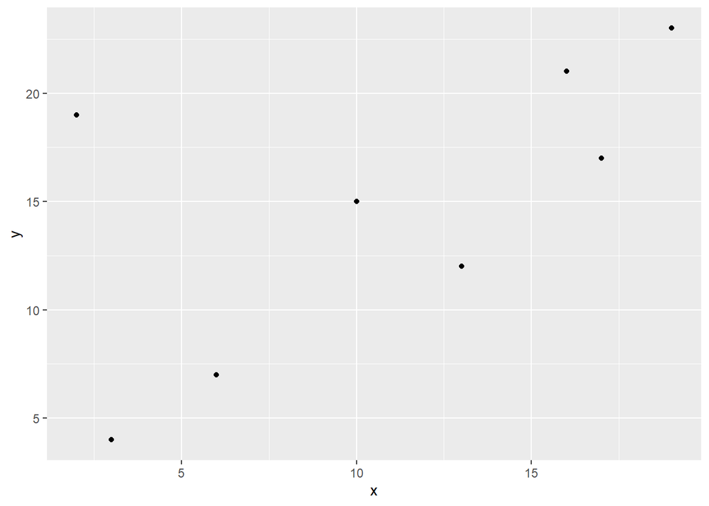

```r
# Create a scatterplot of the dataset
sample %>% ggplot(aes(x = x, y = y)) +
  geom_point()
```

```r
## Steps to calculate  Pearson's correlation coefficient
# Mean and standard deviation of x and y
sumsPearson <- sample %>% summarise(meanx = mean(x), meany = mean(y),stdevx = sd(x), stdevy = sd(y))

# Differences between value and mean for each x and each y
calcPearson <- sample %>%
  summarise(
    diffx = x-sumsPearson$meanx,
    diffy = y-sumsPearson$meany)

# Divide these vectors by the standard deviation
calcPearson <- calcPearson %>%
  mutate(
    diff_sd_x = diffx/sumsPearson$stdevx,
    diff_sd_y = diffy/sumsPearson$stdevy)

# Calculate the product of each value for the above vectors
calcPearson <- calcPearson %>%
  mutate(
    products = diff_sd_x*diff_sd_y)

# Sum these products
sumsPearson <- sumsPearson %>% mutate(sumprods = sum(calcPearson$products))

# Divide by (n-1) to get Pearson's coefficient, here is we will use the length of the x vector as n
sumsPearson <- sumsPearson %>% mutate(Pearson_r = sumprods/(length(x)-1))

# View the tibbles we created
calcPearson
```

```
## # A tibble: 8 × 5
##   diffx  diffy diff_sd_x diff_sd_y products
##   <dbl>  <dbl>     <dbl>     <dbl>    <dbl>
## 1 -7.75 -10.8     -1.18    -1.61    1.90
## 2  6.25   2.25     0.955    0.336   0.321
## 3 -4.75  -7.75    -0.726   -1.16    0.841
## 4  8.25   8.25     1.26     1.23    1.55
## 5 -8.75   4.25    -1.34     0.635  -0.850
## 6  2.25  -2.75     0.344   -0.411  -0.141
## 7  5.25   6.25     0.803    0.934   0.750
## 8 -0.75   0.25    -0.115    0.0374 -0.00428
```

```r
sumsPearson
```

```
## # A tibble: 1 × 6
##   meanx meany stdevx stdevy sumprods Pearson_r
##   <dbl> <dbl>  <dbl>  <dbl>    <dbl>     <dbl>
## 1  10.8  14.8   6.54   6.69     4.37     0.625
```

```r
View(calcPearson)
View(sumsPearson)

## Steps to calculate  Spearman's correlation coefficient
# Calculate the rank of each value of x and y
calcSpearman <- sample %>% mutate(rankx = min_rank(x), ranky = min_rank(y))

# Calculate the difference between ranks for each pair of values
calcSpearman <- calcSpearman %>% mutate(diffrank = rankx - ranky)

# Square that difference
calcSpearman <- calcSpearman %>% mutate(squarediffrank = diffrank^2)

# Sum all squared differences
sumsSpearman <- calcSpearman %>% summarise(sumsquarediff = sum(squarediffrank))

# Multiply by 6/n(n2-1)
sumsSpearman <- sumsSpearman %>% mutate(sumsquarediffmultiplied = sumsquarediff*6/(length(x)*(length(x)^2-1)))

# Subtract this number from 1 to get Spearman's coefficient
sumsSpearman <- sumsSpearman %>% mutate(Spearman_rho = 1-sumsquarediffmultiplied)

# View the tibbles we created
calcSpearman
```

```
## # A tibble: 8 × 6
##       x     y rankx ranky diffrank squarediffrank
##   <dbl> <dbl> <int> <int>    <int>          <dbl>
## 1     3     4     2     1        1              1
## 2    17    17     7     5        2              4
## 3     6     7     3     2        1              1
## 4    19    23     8     8        0              0
## 5     2    19     1     6       -5             25
## 6    13    12     5     3        2              4
## 7    16    21     6     7       -1              1
## 8    10    15     4     4        0              0
```

```r
sumsSpearman
```

```
## # A tibble: 1 × 3
##   sumsquarediff sumsquarediffmultiplied Spearman_rho
##           <dbl>                   <dbl>        <dbl>
## 1            36                   0.429        0.571
```

```r
View(calcSpearman)
View(sumsSpearman)

# Hypothesis testing: t-test on Pearson's correlation coefficient
# t <- sumsPearson$Pearson_r*sqrt((length(x)-2)/(1-(sumsPearson$Pearson_r)^2))

# SHORTCUT: We can make use of R's cor.test() function to avoid all the steps above!
# Calculate Pearson's correlation coefficient and p-value (default method)
cor.test(x,y)
```

```
##
##  Pearson's product-moment correlation
##
## data:  x and y
## t = 1.961, df = 6, p-value = 0.09757
## alternative hypothesis: true correlation is not equal to 0
## 95 percent confidence interval:
##  -0.1424458  0.9231044
## sample estimates:
##       cor
## 0.6249591
```

```r
# This function gives us all at once:
## the method and data used for the test,
## the test statistic, the number of degrees of freedom, the p-value,
## and then the confidence interval and the correlation coefficient.

# Calculate Spearman's correlation coefficient
cor.test(x,y,method="spearman")
```

```
##
##  Spearman's rank correlation rho
##
## data:  x and y
## S = 36, p-value = 0.1511
## alternative hypothesis: true rho is not equal to 0
## sample estimates:
##       rho
## 0.5714286
```

### WK05_TO3

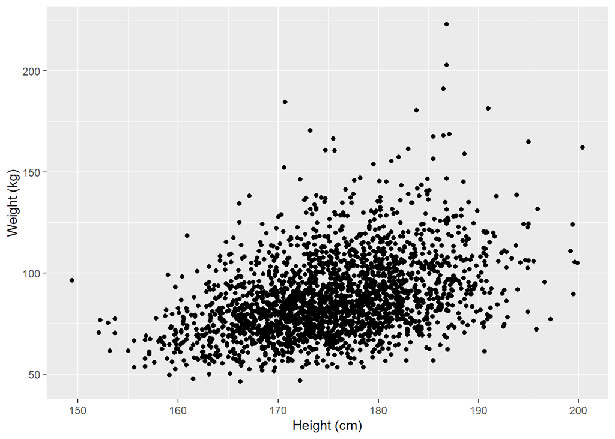

```r
# Take the NHANES dataset, then filter to keep only adult males, then create a scatter plot of Weight against Height
NHANES %>%
  filter(Gender == "male", Age >= 18) %>%
  ggplot(aes(x = Height, y = Weight)) +
  geom_point() +
  xlab("Height (cm)") +
  ylab("Weight (kg)")
```

```r
# Plot a positive regression line
data <- tibble(y=c(8, 9, 10, 9, 11, 14, 15, 13, 14, 15, 17, 16, 19, 18, 20, 21),
                   x=c(0, 1, 2, 2, 3, 4, 4, 5, 6, 6, 8, 9, 9, 11, 12, 12))

png("regression_line.png",width = 165, height = 75, units='mm', res = 300)
ggplot(data,aes(x, y)) +
  geom_point() +
  geom_smooth(method='lm', se=FALSE, color='turquoise4') +
  xlim(0,12.5) +
  theme_bw() +
  labs(x='X Values', y='Y Values')
dev.off()
```

```r
# Fit a linear regression model to the data
lmodel <- lm(y ~ x, data = data)

# Plot the positive regression line with residuals
intercept <- lmodel$coefficients[1]
slope <- lmodel$coefficients[2]
data$fitted <- intercept + slope * data$x

png("regression_line_residuals.png",width = 165, height = 75, units='mm', res = 300)
ggplot(data, aes(x = x, y = y)) +
  geom_abline(slope = slope, intercept = intercept, color = "turquoise4",size=1) +
  geom_segment(aes(xend = x, yend = fitted, color = "resid",size=1)) +
  scale_size_identity() +
  geom_point() +
  theme_bw() +
  theme(legend.position="none") +
  labs(x='X Values', y='Y Values') +
  scale_color_manual(values = c(resid = "darkred"), labels = c(resid = "residuals"))
dev.off()
```

### WK05_TO4 Statistical inference for regression

Understanding Linear Models * A linear model encapsulates the relationship between two variables, often denoted as the explanatory (predictor) variable X and the response variable Y. * The model itself does not imply causation and should be interpreted with caution to avoid making inferences beyond the observed data range. Components of a Linear Model * Slope (β): Indicates the change in the response variable Y for a unit change in the explanatory variable X. A positive slope suggests an increasing trend, while a negative slope indicates a decreasing trend. * Intercept: Represents the value of Y when X is zero. It’s the starting point of the line on the Y-axis. Model Output in R * When running a linear regression in R, the output includes the intercept and slope estimates. These values are crucial for understanding the direction and steepness of the line of best fit. Interactive Visualization * Engaging with interactive tools can deepen understanding by allowing manipulation of data points and observing changes in slope, intercept, and residuals. Evaluating Model Quality * The regression output provides several key statistics for each coefficient (slope and intercept): * Standard Error: Reflects the precision of the coefficient estimate. * T-Value: Measures how many standard deviations the coefficient is from zero. * P-Value: Indicates the probability of observing the given result if the null hypothesis (coefficient equals zero) is true. * 95% Confidence Interval: A range likely to contain the true coefficient value. Narrow intervals that do not include zero suggest a significant relationship. Residual Analysis * Residuals, the differences between observed and predicted values, should ideally be symmetrically distributed around zero. The residual standard error quantifies the average deviation from the regression line, with smaller values indicating a better fit. Model Fit Indicators * Adjusted R-Squared: Represents the proportion of variance in the response variable explained by the predictor. Values closer to one indicate a better model fit.

```r
# Plot a positive regression line
data <- tibble(y=c(8, 9, 10, 9, 11, 14, 15, 13, 14, 15, 17, 16, 19, 18, 20, 21),
               x=c(0, 1, 2, 2, 3, 4, 4, 5, 6, 6, 8, 9, 9, 11, 12, 12))

png("regression_line.png",width = 165, height = 75, units='mm', res = 300)
ggplot(data,aes(x, y)) +
  geom_point() +
  geom_smooth(method='lm', se=FALSE, color='turquoise4') +
  xlim(0,12.5) +
  theme_bw() +
  labs(x='X Values', y='Y Values')
dev.off()
```

```r
# Plot a negative regression line
data <- tibble(y=c(21,20,18,19,16,17,15,14,13,15,14,11,9,10,9,8),
               x=c(0, 1, 2, 2, 3, 4, 4, 5, 6, 6, 8, 9, 9, 11, 12, 12))

png("regression_line_negative.png",width = 165, height = 75, units='mm', res = 300)
ggplot(data,aes(x, y)) +
  geom_point() +
  geom_smooth(method='lm', se=FALSE, color='turquoise4') +
  xlim(0,12.5) +
  theme_bw() +
  labs(x='X Values', y='Y Values')
dev.off()
```

```r
# Fit a linear model to the data
lmodel <- lm(y ~ x, data = data)
lmodel$coefficients
```

```
## (Intercept)           x
##   20.229053   -1.007073
```

```r
summary(lmodel)
```

```
##
## Call:
## lm(formula = y ~ x, data = data)
##
## Residuals:
##     Min      1Q  Median      3Q     Max
## -2.1654 -1.1884  0.3134  0.8028  1.8275
##
## Coefficients:
##             Estimate Std. Error t value Pr(>|t|)
## (Intercept) 20.22905    0.52914   38.23 1.46e-15 ***
## x           -1.00707    0.07569  -13.31 2.46e-09 ***
## ---
## Signif. codes:  0 '***' 0.001 '**' 0.01 '*' 0.05 '.' 0.1 ' ' 1
##
## Residual standard error: 1.147 on 14 degrees of freedom
## Multiple R-squared:  0.9267, Adjusted R-squared:  0.9215
## F-statistic:   177 on 1 and 14 DF,  p-value: 2.458e-09
```

```r
confint(lmodel)
```

```
##                 2.5 %     97.5 %
## (Intercept) 19.094170 21.3639369
## x           -1.169406 -0.8447395
```

### WK05_T05

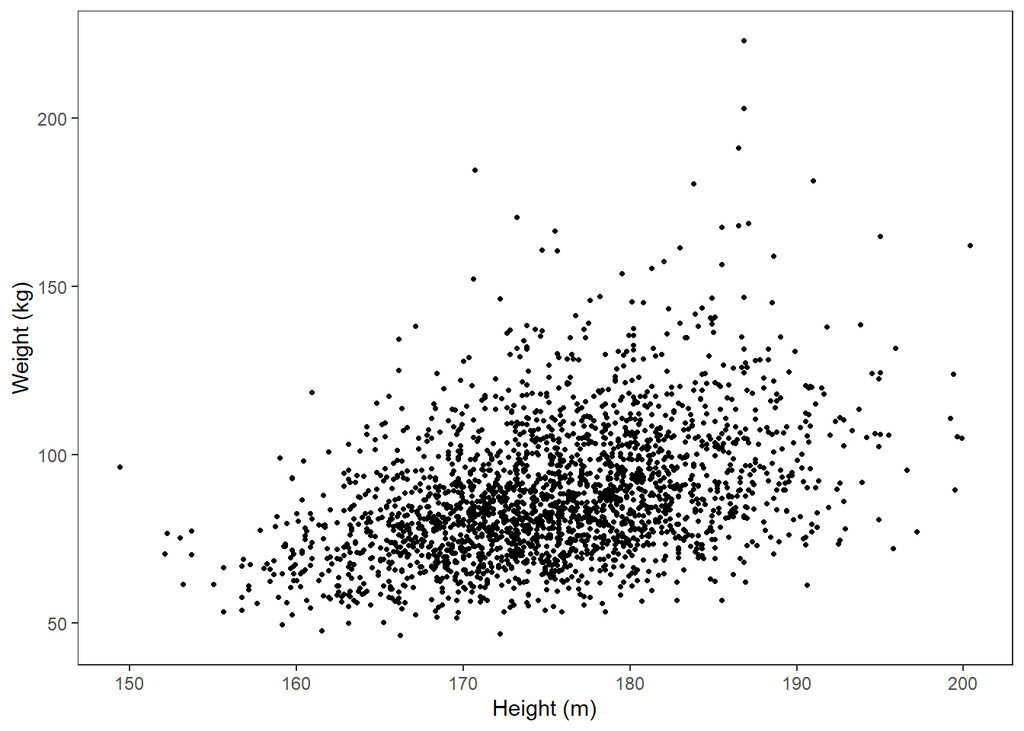

```r
# Create a subset of the NHANES dataset with only male individuals aged 18 and over,
# who have both Height and Weight information
subsetNHANES <-NHANES %>%
  filter(Gender == "male", Age >= 18) %>%
  drop_na(Height,Weight) %>% # remove rows where either Height or Weight is NA
  select(Height,Weight)

# Create a scatterplot for Height (x axis) and Weight (y axis)
subsetNHANES %>%
  ggplot(aes(x = Height, y = Weight)) +
  geom_point(pch=20) + # plot the data points and change the dot shape / size
  xlab("Height (m)") +
  ylab("Weight (kg)") +
  theme_bw() +                       ## remove gray background
  theme(panel.grid=element_blank())  ## remove grid
```

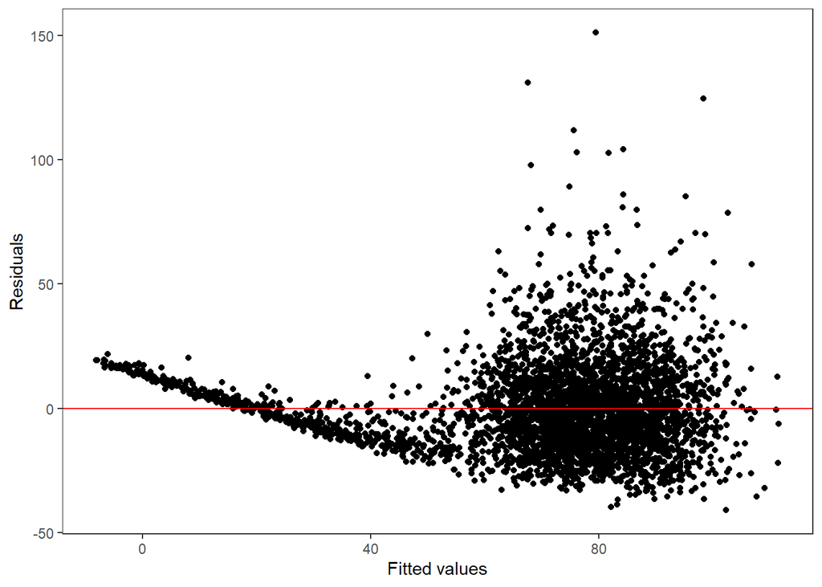

```r
# Create a subset of the NHANES dataset with 5000 random individuals
# who have both Height and Weight information
subsetNHANES <-NHANES %>%
  sample_n(5000) %>%
  drop_na(Height,Weight) %>% # remove rows where either Height or Weight is NA
  select(Height,Weight)

# Fit a regression model to predict Weight from Height
model <- lm(Weight~Height, data=subsetNHANES)

# Get a list of residuals for that model
res <- resid(model)

# Produce a residual vs. fitted plot
ggplot(model, aes(x = .fitted, y = .resid)) +
  geom_point() +
  geom_hline(aes(yintercept=0),color="red") +
  labs(y='Residuals',x='Fitted values') +
  theme_bw() +                       ## remove gray background
  theme(panel.grid=element_blank())  ## remove grid
```

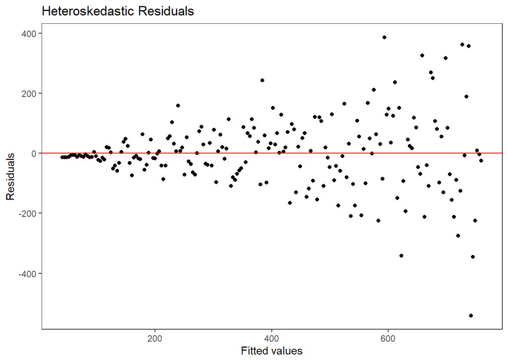

```r
## Made up data to create residual plots for normal and non-normal residuals
set.seed(127) # This sets a seed of 127 so the random data will remain the same
# Create a vector x for numbers 1 to 200
x<-seq(1,200,1)

# Create an error term dependent on x named err
err<-NULL
for(i in c(1:200)) {
  err[i]<-rnorm(1,0,i)
}
# Calculate y using the equation y = 3.8x + 25 + err
y<-3.8*x+25+err

# Linear regression to predict y from x
naivelm<-lm(y~x)

# Calculate the absolute value of the linear model's residuals
absresid<-abs(naivelm$residuals)

# Constant variability
# Create a normally distributed error term called errno
errno<-NULL
for(i in c(1:200)) {
  errno[i]<-rnorm(1,0,15)
}
# Calculate yn using the equation y = 3.8x + 25 + errno
yn<-3.8*x+25+errno

# Linear regression to predict yn from x
normallm<-lm(yn~x)

## Residual plots for both models, displayed one above the other
par(mfrow=c(2,1))
# Residual plot for naivelm, non-constant variability
ggplot(naivelm, aes(x = .fitted, y = .resid)) +
  geom_point() +
  geom_hline(aes(yintercept=0),color="red") +
  labs(title="Heteroskedastic Residuals",y='Residuals',x='Fitted values') +
  theme_bw() +                       ## remove gray background
  theme(panel.grid=element_blank())  ## remove grid
```

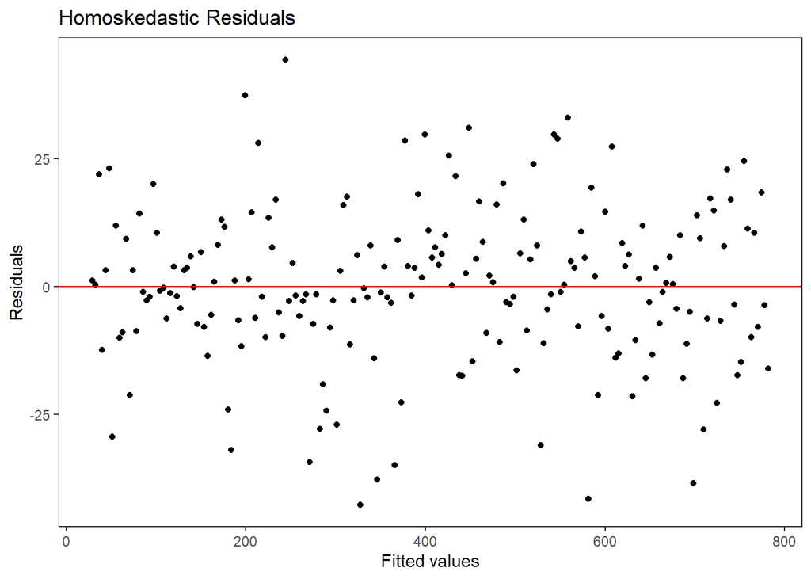

```r
# Residual plot for normallm, constant variability
ggplot(normallm, aes(x = .fitted, y = .resid)) +
  geom_point() +
  geom_hline(aes(yintercept=0),color="red") +
  labs(title="Homoskedastic Residuals",y='Residuals',x='Fitted values') +
  theme_bw() +                       ## remove gray background
  theme(panel.grid=element_blank())  ## remove grid
```

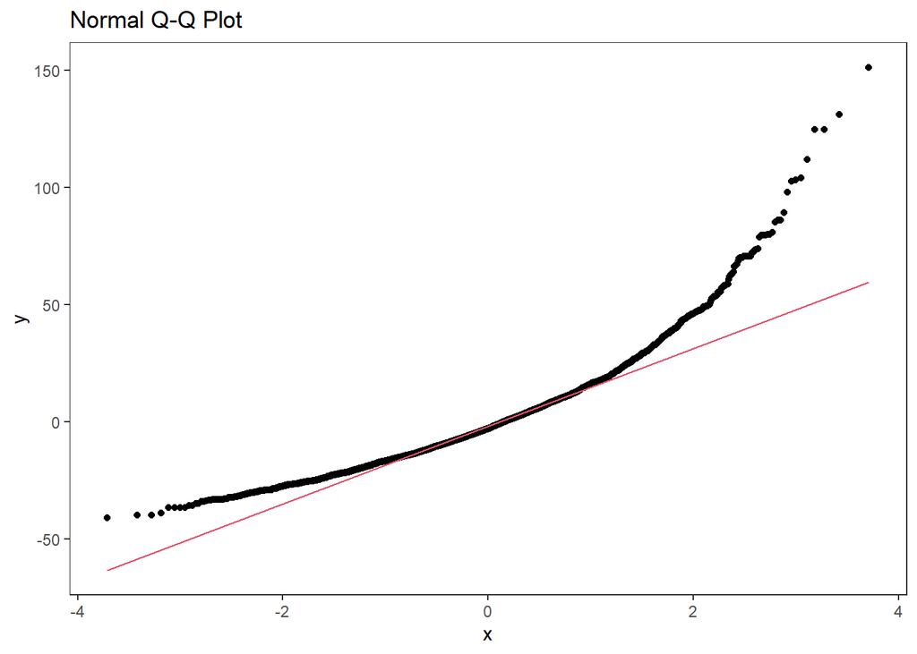

```r
# Normality of residuals for model for subsetNHANES to predict Weight from Height
# Create a Q-Q plot
model %>%
  ggplot(aes(sample=.resid)) +
  stat_qq() +
  stat_qq_line(color=2) +
  labs(title="Normal Q-Q Plot") +    ## add title
  theme_bw() +                       ## remove gray background
  theme(panel.grid=element_blank())  ## remove grid
```

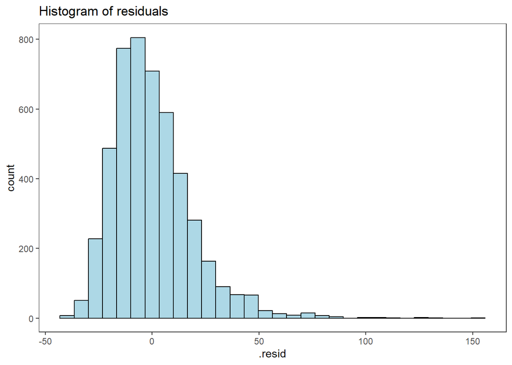

```r
# Create a histogram
model %>%
  ggplot(aes(x=.resid)) +
  geom_histogram(col="black",fill="lightblue",bins = 30) +
  labs(title="Histogram of residuals") +    ## add title
  theme_bw() +                       ## remove gray background
  theme(panel.grid=element_blank())  ## remove grid
```

### WK05_Code along

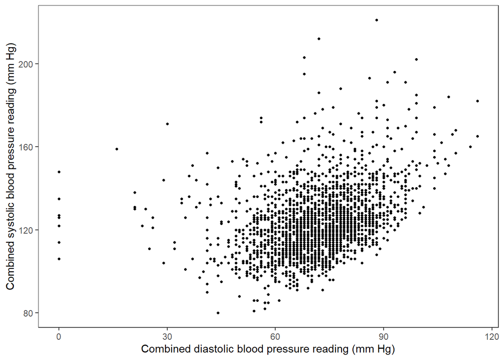

```r
# Demonstration of testing the association between two numerical variables
# and checking of assumptions for regression and t-tests

# Load the tidyverse package
library(tidyverse)

# Install the NHANES package with the dataset (only do this once!)
# install.packages("NHANES")

# Load the NHANES package
library(NHANES)

###############################################################################
# EXAMPLE 1: Investigate the relationship between BPDiaAve and BPSysAve in
#            adult males
###############################################################################

# Create a subset of the NHANES dataset with only male individuals aged 18 and over,
# who have both BPDiaAve and BPSysAve information
subsetNHANES2 <-NHANES %>%
  filter(Gender == "male", Age >= 18) %>%
  drop_na(BPDiaAve,BPSysAve) %>% # remove rows where either BPDiaAve or BPSysAve is NA
  select(BPDiaAve,BPSysAve)

# Create a scatterplot for BPDiaAve (x axis) and BPSysAve (y axis)
subsetNHANES2 %>%
  ggplot(aes(x = BPDiaAve, y = BPSysAve)) +
  geom_point(pch=20) + # plot the data points and change the dot shape / size
  xlab("Combined diastolic blood pressure reading (mm Hg)") +
  ylab("Combined systolic blood pressure reading (mm Hg)") +
  theme_bw() +                       ## remove gray background
  theme(panel.grid=element_blank())  ## remove grid
```

```r
# Calculate Pearson's correlation coefficient between BPDiaAve and BPSysAve
# and display the output as a tibble (table) with columns for the coefficient
# estimate, t-statistic, p-value, degrees of freedom, lower and upper bound of
# the 95% confidence interval

# subsetNHANES2 %>%
#   summarize(Pearsonr = cor.test(BPDiaAve,BPSysAve,method="pearson")$estimate,
#             tstat = cor.test(BPDiaAve,BPSysAve,method="pearson")$statistic,
#             pval = cor.test(BPDiaAve,BPSysAve,method="pearson")$p.value,
#             df = cor.test(BPDiaAve,BPSysAve,method="pearson")$parameter,
#             lowerCI = cor.test(BPDiaAve,BPSysAve,method="pearson")$conf.int[1],
#             upperCI = cor.test(BPDiaAve,BPSysAve,method="pearson")$conf.int[2])

# Base R alternative to get the same information
with(subsetNHANES2,cor.test(BPDiaAve,BPSysAve,method="pearson"))
```

```
##
##  Pearson's product-moment correlation
##
## data:  BPDiaAve and BPSysAve
## t = 23.849, df = 3579, p-value < 2.2e-16
## alternative hypothesis: true correlation is not equal to 0
## 95 percent confidence interval:
##  0.3416929 0.3982275
## sample estimates:
##       cor
## 0.3703031
```

```r
cor.test(subsetNHANES2$BPDiaAve,subsetNHANES2$BPSysAve,method="pearson")
```

```
##
##  Pearson's product-moment correlation
##
## data:  subsetNHANES2$BPDiaAve and subsetNHANES2$BPSysAve
## t = 23.849, df = 3579, p-value < 2.2e-16
## alternative hypothesis: true correlation is not equal to 0
## 95 percent confidence interval:
##  0.3416929 0.3982275
## sample estimates:
##       cor
## 0.3703031
```

```r
# Calculate Spearman's correlation coefficient between BPDiaAve and BPSysAve
# and display the output as a tibble (table) with columns for the coefficient
# estimate, S-statistic, and p-value

# subsetNHANES2 %>%
#   summarize(Spearmanrho = cor.test(BPDiaAve,BPSysAve,method="spearman")$estimate,
#             Sstat = cor.test(BPDiaAve,BPSysAve,method="spearman")$statistic,
#             pval = cor.test(BPDiaAve,BPSysAve,method="spearman")$p.value)

# Base R alternative to get the same information
with(subsetNHANES2,cor.test(BPDiaAve,BPSysAve,method="spearman"))
```

```
##
##  Spearman's rank correlation rho
##
## data:  BPDiaAve and BPSysAve
## S = 4606366991, p-value < 2.2e-16
## alternative hypothesis: true rho is not equal to 0
## sample estimates:
##       rho
## 0.3981381
```

```r
# You will get a warning here as there are too many ties for the ranks so R cannot
# compute an exact p-value

# Build a linear regression model to predict BPSysAve based on BPDiaAve
# using the subsetNHANES dataset and save the output as an object called lmodel
lmodel <- lm(BPSysAve ~ BPDiaAve, data = subsetNHANES2)

# Display the coefficients (b0: intercept and b1: slope) for the model
lmodel$coefficients
```

```
## (Intercept)    BPDiaAve
##  88.8720082   0.4722754
```

```r
# Display the 95% confidence intervals for each coefficient (beta 0 and beta 1)
confint(lmodel)
```

```
##                  2.5 %     97.5 %
## (Intercept) 86.0500304 91.6939861
## BPDiaAve     0.4334491  0.5111018
```

```r
# Display a summary of the linear model, including: the variables and dataset
# used; summary statistics for the distribution of the residuals; the coefficient
# estimates and their associated standard error, t-value and p-value; model
# measure of quality (e.g. residual standard error, adjusted R-squared and F statistic)
summary(lmodel)
```

```
##
## Call:
## lm(formula = BPSysAve ~ BPDiaAve, data = subsetNHANES2)
##
## Residuals:
##     Min      1Q  Median      3Q     Max
## -33.792  -9.654  -2.736   6.874  90.568
##
## Coefficients:
##             Estimate Std. Error t value Pr(>|t|)
## (Intercept)  88.8720     1.4393   61.75   <2e-16 ***
## BPDiaAve      0.4723     0.0198   23.85   <2e-16 ***
## ---
## Signif. codes:  0 '***' 0.001 '**' 0.01 '*' 0.05 '.' 0.1 ' ' 1
##
## Residual standard error: 14.77 on 3579 degrees of freedom
## Multiple R-squared:  0.1371, Adjusted R-squared:  0.1369
## F-statistic: 568.8 on 1 and 3579 DF,  p-value: < 2.2e-16
```

```r
## The coefficients are significantly different from 0. But the model only explains
## 13% of the variances in the response variable BPSysAve.

# Using that linear regression model, predict the average systolic blood pressure
# value for an adult male with average diastolic blood pressure of 100 mm Hg
predict(lmodel, newdata = data.frame(BPDiaAve=c(100)),se.fit = T)
```

```
## $fit
##        1
## 136.0996
##
## $se.fit
## [1] 0.6140495
##
## $df
## [1] 3579
##
## $residual.scale
## [1] 14.7664
```

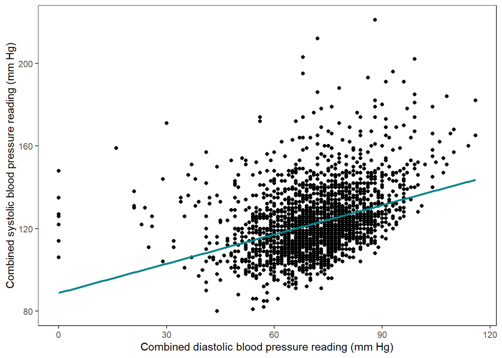

```r
# Create the scatterplot, and this time add the regression line to it
subsetNHANES2 %>%
  ggplot(aes(x = BPDiaAve, y = BPSysAve)) +
  geom_point() +
  xlab("Combined diastolic blood pressure reading (mm Hg)") +
  ylab("Combined systolic blood pressure reading (mm Hg)") +
  geom_smooth(method='lm', se=FALSE, color='turquoise4') +
  theme_bw() +
  theme(panel.grid=element_blank())
```

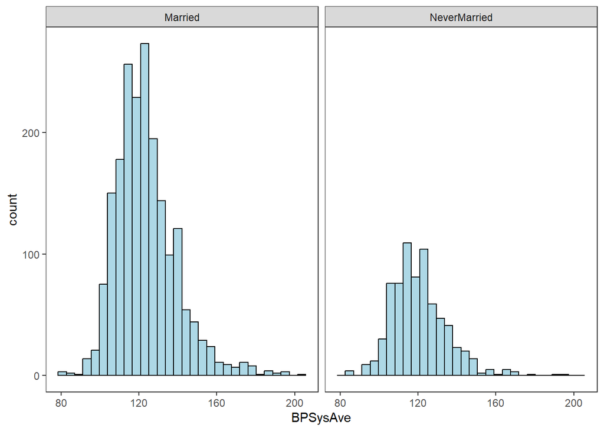

```r
###############################################################################
# EXAMPLE 2: Check the assumptions for a t-test comparing BPSysAve between
#            Married and Never Married from the MaritalStatus variable for adult
#            males
###############################################################################

# Create a subset of the NHANES dataset with only male individuals aged 18 and over,
# who have BPSysAve information and MaritalStatus either Married or NeverMarried
subsetNHANES2 <-NHANES %>%
  filter(Gender == "male"& Age >= 18 &
           MaritalStatus %in% c("Married","NeverMarried")) %>%
  drop_na(BPSysAve) %>% # remove rows where BPSysAve is NA
  select(MaritalStatus,BPSysAve)

# 1. Assumption of normal distribution of variables

# Plot a histogram for BPSysAve for each marital status
# the facets - by facet grid to separate the two marital statuses
subsetNHANES2 %>%
  ggplot(aes(x = BPSysAve)) +
  geom_histogram(col="black",fill="lightblue",bins = 30 ) +
  facet_grid(~MaritalStatus) +
  theme_bw() +                       ## remove gray background
  theme(panel.grid=element_blank())  ## remove grid
```

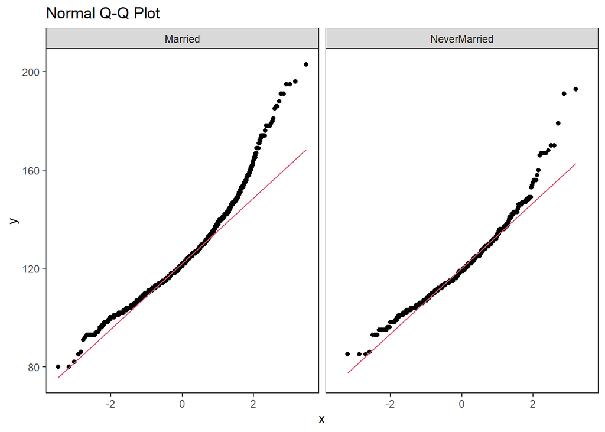

```r
# Create a Normal Q-Q plot for BPSysAve
subsetNHANES2 %>%
  ggplot(aes(sample=BPSysAve)) +
  stat_qq() +
  stat_qq_line(color=2) +
  facet_grid(~MaritalStatus) +
  labs(title="Normal Q-Q Plot") +    ## add title
  theme_bw() +                       ## remove gray background
  theme(panel.grid=element_blank())  ## remove grid
```